# **Data visualisation on HONEY PRODUCTION**. - Python Project WK03

By: SONAL KUMARI

# PART II:

# HONEY PRODUCTION

### 1. Import required libraries and read the dataset.

```python
#Importing all necessary libraries
import pandas as pd
import matplotlib.pyplot as plt
import seaborn as sns

import warnings
warnings.filterwarnings('ignore')
```

```python
# loading dataset into Dataframe = pd.read_csv("honeyproduction .csv")
data = pd.read_csv("honeyproduction .csv")
```

```python
data
```

|  | state | numcol | yieldpercol | totalprod | stocks | priceperlb | prodvalue | year |
| --- | --- | --- | --- | --- | --- | --- | --- | --- |
| 0 | AL | 16000.0 | 71 | 1136000.0 | 159000.0 | 0.72 | 818000.0 | 1998 |
| 1 | AZ | 55000.0 | 60 | 3300000.0 | 1485000.0 | 0.64 | 2112000.0 | 1998 |
| 2 | AR | 53000.0 | 65 | 3445000.0 | 1688000.0 | 0.59 | 2033000.0 | 1998 |
| 3 | CA | 450000.0 | 83 | 37350000.0 | 12326000.0 | 0.62 | 23157000.0 | 1998 |
| 4 | CO | 27000.0 | 72 | 1944000.0 | 1594000.0 | 0.70 | 1361000.0 | 1998 |
| ... | ... | ... | ... | ... | ... | ... | ... | ... |
| 621 | VA | 4000.0 | 41 | 164000.0 | 23000.0 | 3.77 | 618000.0 | 2012 |
| 622 | WA | 62000.0 | 41 | 2542000.0 | 1017000.0 | 2.38 | 6050000.0 | 2012 |
| 623 | WV | 6000.0 | 48 | 288000.0 | 95000.0 | 2.91 | 838000.0 | 2012 |
| 624 | WI | 60000.0 | 69 | 4140000.0 | 1863000.0 | 2.05 | 8487000.0 | 2012 |
| 625 | WY | 50000.0 | 51 | 2550000.0 | 459000.0 | 1.87 | 4769000.0 | 2012 |

626 rows × 8 columns

### 2. Check the first few samples, shape, info of the data and try to familiarize yourself with different features.

```python
# Checking the head of the data
data.head()
```

|  | state | numcol | yieldpercol | totalprod | stocks | priceperlb | prodvalue | year |
| --- | --- | --- | --- | --- | --- | --- | --- | --- |
| 0 | AL | 16000.0 | 71 | 1136000.0 | 159000.0 | 0.72 | 818000.0 | 1998 |
| 1 | AZ | 55000.0 | 60 | 3300000.0 | 1485000.0 | 0.64 | 2112000.0 | 1998 |
| 2 | AR | 53000.0 | 65 | 3445000.0 | 1688000.0 | 0.59 | 2033000.0 | 1998 |
| 3 | CA | 450000.0 | 83 | 37350000.0 | 12326000.0 | 0.62 | 23157000.0 | 1998 |
| 4 | CO | 27000.0 | 72 | 1944000.0 | 1594000.0 | 0.70 | 1361000.0 | 1998 |

```python
# checking the shape of the data
data.shape
```

```
(626, 8)
```

```python
# checking the information about data and it's dtypes
data.info
```

[output not shown]

```python
#Checking Desciptive statistics of the data
data.describe()
```

|  | numcol | yieldpercol | totalprod | stocks | priceperlb | prodvalue | year |
| --- | --- | --- | --- | --- | --- | --- | --- |
| count | 626.000000 | 626.000000 | 6.260000e+02 | 6.260000e+02 | 626.000000 | 6.260000e+02 | 626.000000 |
| mean | 60284.345048 | 62.009585 | 4.169086e+06 | 1.318859e+06 | 1.409569 | 4.715741e+06 | 2004.864217 |
| std | 91077.087231 | 19.458754 | 6.883847e+06 | 2.272964e+06 | 0.638599 | 7.976110e+06 | 4.317306 |
| min | 2000.000000 | 19.000000 | 8.400000e+04 | 8.000000e+03 | 0.490000 | 1.620000e+05 | 1998.000000 |
| 25% | 9000.000000 | 48.000000 | 4.750000e+05 | 1.430000e+05 | 0.932500 | 7.592500e+05 | 2001.000000 |
| 50% | 26000.000000 | 60.000000 | 1.533000e+06 | 4.395000e+05 | 1.360000 | 1.841500e+06 | 2005.000000 |
| 75% | 63750.000000 | 74.000000 | 4.175250e+06 | 1.489500e+06 | 1.680000 | 4.703250e+06 | 2009.000000 |
| max | 510000.000000 | 136.000000 | 4.641000e+07 | 1.380000e+07 | 4.150000 | 6.961500e+07 | 2012.000000 |

### 3. Display the percentage distribution of the data in each year using the pie chart.

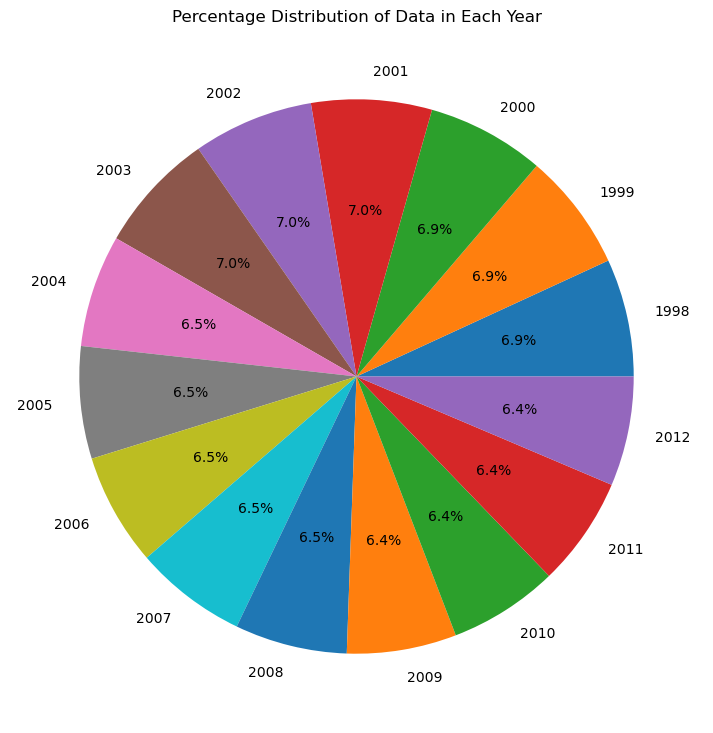

```python
# To display the percentage distribution of the data in each year using the pie chart
year_perdist = data.groupby('year').size()/len(data)*100

# plotting the pie chart
plt.figure(figsize=(9,9))
plt.pie(year_perdist, labels=year_perdist.index, autopct='%1.1f%%')
plt.title('Percentage Distribution of Data in Each Year')
plt.show()
```

### 4. Plot and Understand the distribution of the variable "price per lb" using displot, and write your findings.

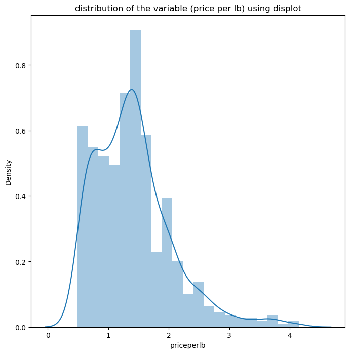

```python
# plotting the distibution of "price per lb" variable using displot
plt.figure(figsize=(8,8))
sns.distplot(data['priceperlb'])
plt.title("distribution of the variable (price per lb) using displot")
plt.show()
```

It is observed that the most common value of price per lb is 1.5 dollars having nearly 100 counts and the least common value is 3.9 dollars having nearly 1 count. The distribution of average price per pound of honey production is positively skewed and is unimodal in nature.

### 5. Plot and understand the relationship between the variables 'numcol' and 'prodval' through scatterplot, and write your findings.

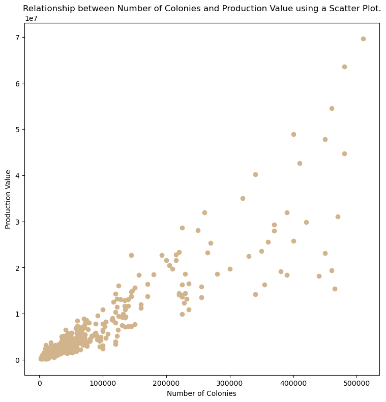

```python
# plotting scatterplot to understand the relationship between the variables 'numcol' and 'prodval'
plt.figure(figsize=(9,9))
plt.scatter(data['numcol'], data['prodvalue'],color = "tan")
plt.xlabel('Number of Colonies')
plt.ylabel('Production Value')
plt.title('Relationship between Number of Colonies and Production Value using a Scatter Plot.')
plt.show()
```

It is observed that the numcol and prodval variables have a positive relationship as seen from the scatterplot. With the increase in numcol, the prodval also increases.

Thus, it can be concluded that with the increase in number of honey producing colonies the value of production also increases.

### 6. Plot and understand the relationship between categorical variable 'year' and a numerical variable 'prodvalue' through boxplot, and write your findings.

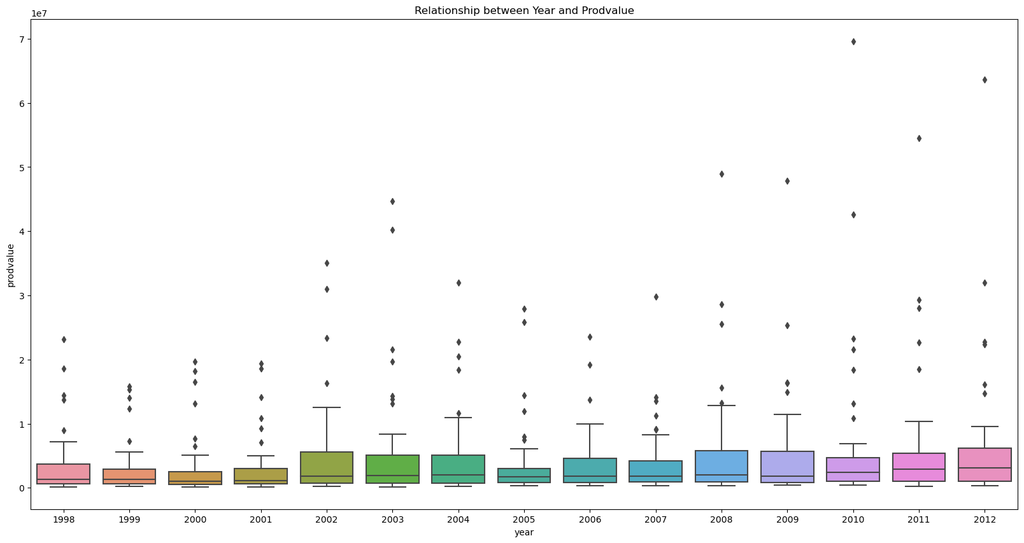

```python
# plotting a boxplots to understand the relationship between year and prodvalue
plt.figure(figsize=(20,10))
sns.boxplot(x='year', y='prodvalue', data=data)
plt.title('Relationship between Year and Prodvalue')
plt.show()
```

### 7. Visualize and understand the relationship between the multiple pairs of variables throughout different years using pairplot and add your inferences. (use columns 'numcol', 'yield percol', 'total prod', 'prodvalue','year')

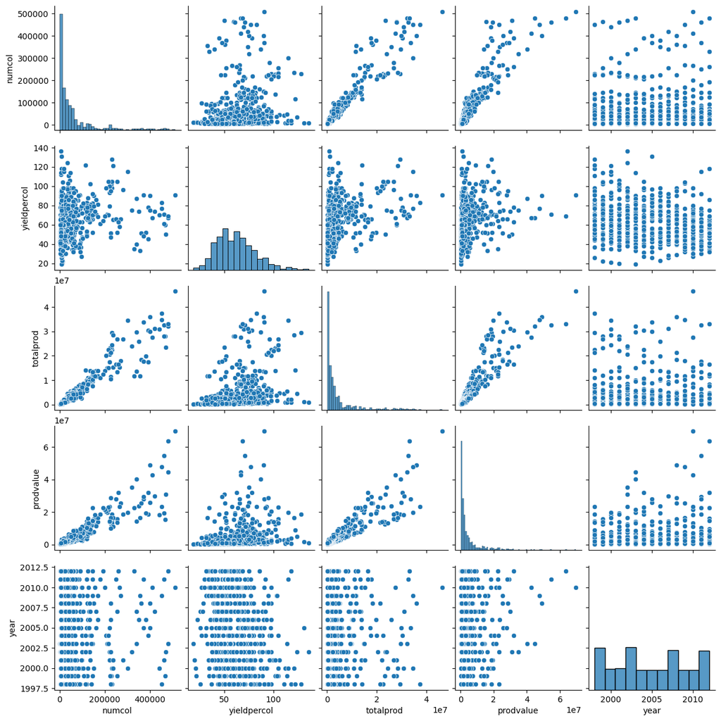

```python
# understanding the relationship between multiple pairs of variables using pairplot
sns.pairplot(data, vars=['numcol', 'yieldpercol', 'totalprod', 'prodvalue', 'year'])
```

It is observed from the pairplot that the numcol has positive linear relationship with totalprod and prodvalue. Also, there is positive linear relationship between prodvalue and totalprod.

### 8. Display the correlation values using a plot and add your inferences. (use columns 'numcol', 'yield percol', 'total prod', 'stocks', 'price per lb', 'prodvalue')

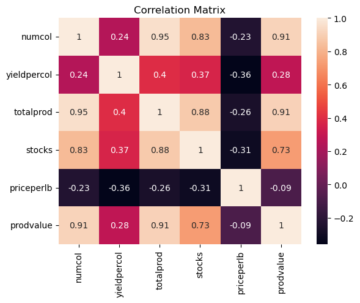

```python
#create a subset of the dataframe
data_subset = data[['numcol', 'yieldpercol', 'totalprod', 'stocks', 'priceperlb', 'prodvalue']]

#calculating correlation matrix
corr_matrix = data_subset.corr()

#plotting the heatmap
sns.heatmap(corr_matrix, annot=True)
plt.title("Correlation Matrix")
plt.show()
```

It is seen from the correaltion matrix that:

There is strong positive correlation between numcol and totalprod with value of correlation coeffiecient equal to 0.95. Followed by it, there is strong correlation between numcol and prodvalue with value of correlation coeffiecient equal to 0.91. * There is strong positive correlation between totalprod and prodvalue with value of correlation coeffiecient equal to 0.91. There is strong positive correlation between totalprod and stocks with value of correlation coeffiecient equal to 0.88. There is strong positive correlation between numcol and stocks with value of correlation coeffiecient equal to 0.83. There is positive correlation between stocks and prodvalue with value of correlation coeffiecient equal to 0.73. The correlation between other variables are weaker when compared to between these variables. There is weaker negative correlation between pricelb and numcol, yieldpercol, totalprod, stocks and prodvalue.